# Namibian hake model update, 2026

Author

John Kathena, Jim Ianelli

Published

July 31, 2026

# Executive summary

## Summary of changes in assessment inputs

The accepted 2025 model configuration was extended through 2026 without changing the base-model assumptions. The update adds the 2026 catch, CPUE, survey biomass, and composition rows provided in `namhakdata26.dat`. The species-specific survey series in `CapeHakes.csv` was extended through 2026 for *Merluccius paradoxus* and *M. capensis*.

Automated checks confirmed continuous annual ADMB matrices from 1964 through 2026, the expected dimensions of all weight, catch, composition, CPUE, and survey blocks, agreement among all terminal-year controls, and valid `54321` and `12345` end-of-file sentinels.

## Summary of results

The 2026 base model converged with an objective function of -16.852, a maximum gradient of 1.41e-04, and a positive-definite Hessian. Estimated terminal spawning biomass was 467 and terminal spawning biomass relative to BMSY was 0.497.

All six sensitivity configurations met the same convergence criteria as the base model. After the selectivity slopes were estimated on the log scale with a first-difference smoothing penalty, the dome-shaped selectivity case converged with a maximum gradient below 0.001 and a positive-definite Hessian.

No TAC, ABC, or OFL recommendation is made in this document. Those quantities require the agreed Namibian management procedure and management inputs.

Table 1: Comparison of 2025 values from the previous assessment with 2026 values from the updated assessment.

| Quantity | Previous assessment (2025 value) | Updated assessment (2026 value) | Change (2026 minus 2025) |
| --- | --- | --- | --- |
| SSB | 490.867 | 466.951 | -23.916 |
| Depletion | 0.172 | 0.165 | -0.008 |
| B_Bmsy | 0.521 | 0.497 | -0.024 |
| Catch | 140.001 | 133.001 | -7.000 |
| RY | 104.865 | 98.766 | -6.099 |
| Catch_RY | 1.335 | 1.347 | 0.012 |

# Introduction

This operational update applies the 2025 base-model structure to information available through 2026. Stable model methods are not repeated in full; the emphasis is on new inputs, bridge results, model diagnostics, and sensitivity to the principal structural assumptions considered in the previous assessment.

# Fishery and management history

The assessment input contains annual catches from 1964 through 2026. Management-history text and the final 2026 management decision should be inserted following review by MFMR.

# Data

Table 2: Automated validation of the 2026 model inputs.

| Check | Result |
| --- | --- |
| Annual model years | 1964–2026 |
| Weight-at-age dimensions | 63 × 10 |
| Fishery composition dimensions | 63 × 11 |
| CPUE dimensions | 63 × 7 |
| Survey dimensions | 63 × 5 |
| Control EOF sentinel | 54321 |
| Data EOF sentinel | 12345 |

## Survey data

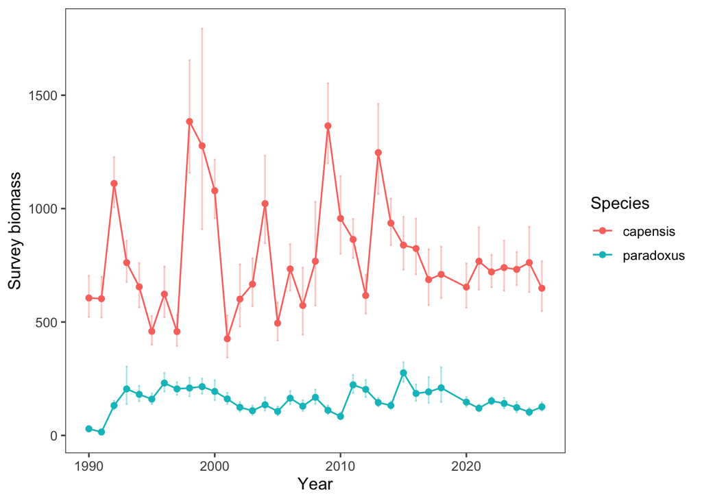

Figure 1: Species-specific survey biomass observations through 2026.

## Other data

No additional external data series were introduced in this update. Missing survey observations remain represented as missing or zero according to the existing model input convention; no values were imputed to create artificial annual continuity.

# Analytic approach

The age-structured ADMB model and 2025 base assumptions were retained. The control file specifies the terminal year in four locations: the model terminal year, final selectivity period, final recruitment-estimation year, and final Ksp period. All four are set to 2026.

The bridge comparison changes only the data and terminal year. Sensitivities fix survey catchability at 1.0 and 0.5, estimate natural mortality, allow dome-shaped fishery selectivity, and fix stock-recruit steepness at 0.5 and 0.9. Convergence requires a finite objective, maximum gradient no greater than 0.001, and a positive-definite ADMB Hessian.

# Results

## Bridge comparison

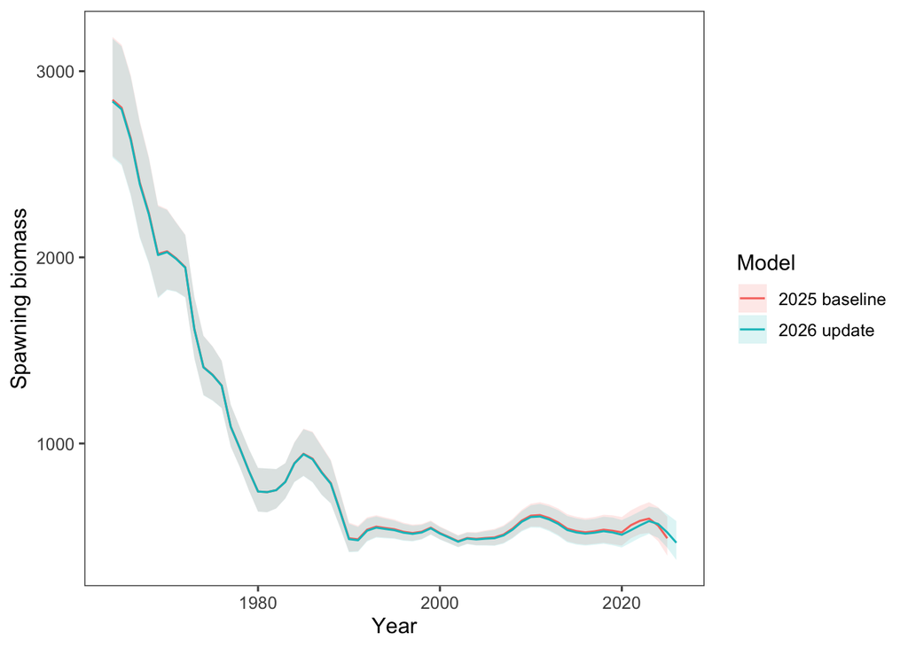

Figure 2: Spawning biomass from the unchanged 2025 model and the 2026 data update.

As shown in Figure 2, adding the 2026 observations caused only modest revisions to the historical spawning-biomass trajectory. For the common terminal year 2025, the updated model estimated spawning biomass at 522, compared with 491 in the previous assessment—an increase of approximately 6.4%. Despite this upward revision to the 2025 estimate, the updated trajectory continued downward to 467 in 2026.

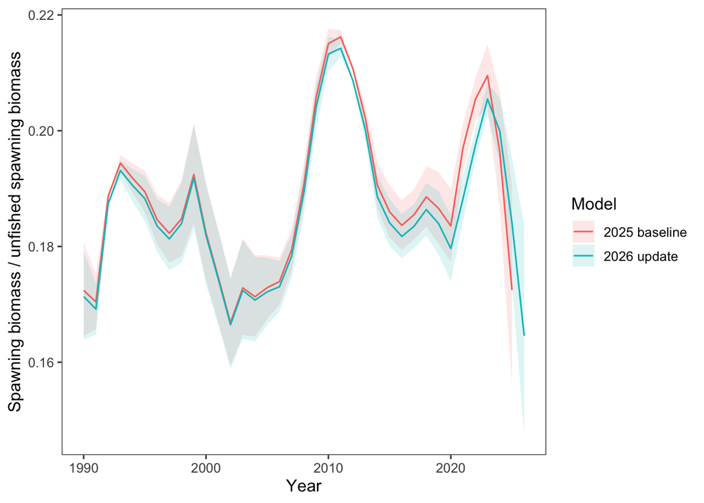

Figure 3: Estimated depletion from the 2025 baseline and 2026 update.

The same result is apparent on the relative scale in Figure 3. Estimated 2025 depletion increased from 0.172 in the previous model to 0.184 after the data update, before declining to 0.165 in 2026. The overlapping uncertainty intervals and closely aligned historical series indicate that the update changes the recent endpoint more than the overall interpretation of the stock trajectory.

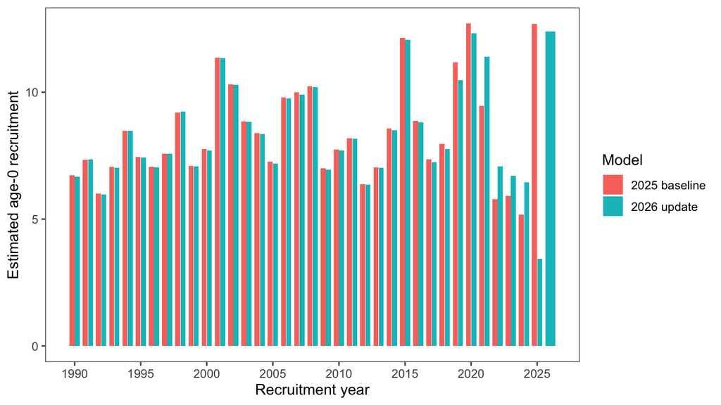

Figure 4: Estimated age-0 recruitment from the 2025 baseline and 2026 update, 1990–2026. The 2026 bar is available only for the updated model.

Recruitment estimates are very similar over most of the shared time series (Figure 4), consistent with the limited historical revisions in the biomass bridge. The update produces more visible revisions in the most recent years: estimated 2025 recruitment decreases from 12.69 to 3.44, while the updated model estimates 2026 recruitment at 12.4. The apparent 2026 increase should be interpreted cautiously because it is the new terminal recruitment estimate and is consequently informed by less data than earlier cohorts.

## Time-varying fishery selectivity

The following figures use the year-normalized gradient ridge-plot presentation from the pollock model to compare time-varying fishery selectivity from the converged 2026 base model with the dome-shaped sensitivity. The same colour scale is used in both figures.

For the dome-shaped sensitivity, the descending-limb slope in selectivity period (p) was reparameterized as

$$d_p = \exp(\eta_p),$$

where $\eta_p$ is the estimated `log_SelSlope` and $d_p$ is the positive descending slope used by the model. For ages at or above the specified onset age $a_d$, the ascending logistic selectivity $L_p(a)$ is modified as

$$\widetilde S_p(a) =
L_p(a)\exp\{-d_p(a-a_d)\}, \qquad a \geq a_d,$$

and the complete age-specific curve is subsequently normalized to have a maximum of one. Estimating $\eta_p$, rather than directly estimating a bounded $d_p$, guarantees a positive descending slope and removes numerical behavior associated with a slope estimate approaching a boundary.

Two penalties stabilize the period-specific estimates. The existing shrinkage penalty controls their overall magnitude,

$$P_{\mathrm{level}} =
12.5\sum_{p=1}^{P}(d_p-0.5)^2,$$

while a first-difference penalty on the log slopes discourages abrupt changes between adjacent selectivity periods,

$$P_{\mathrm{smooth}} =
\frac{1}{2}\sum_{p=2}^{P}
\left(\frac{\eta_p-\eta_{p-1}}{0.15}\right)^2.$$

These modifications retain time variation and permit dome-shaped curves, but reduce confounding among poorly informed period-specific slopes and the other parameters controlling the location and width of selectivity. In the final run, the regularized dome-shaped model had a maximum gradient of 3.39e-05 and a positive-definite Hessian.

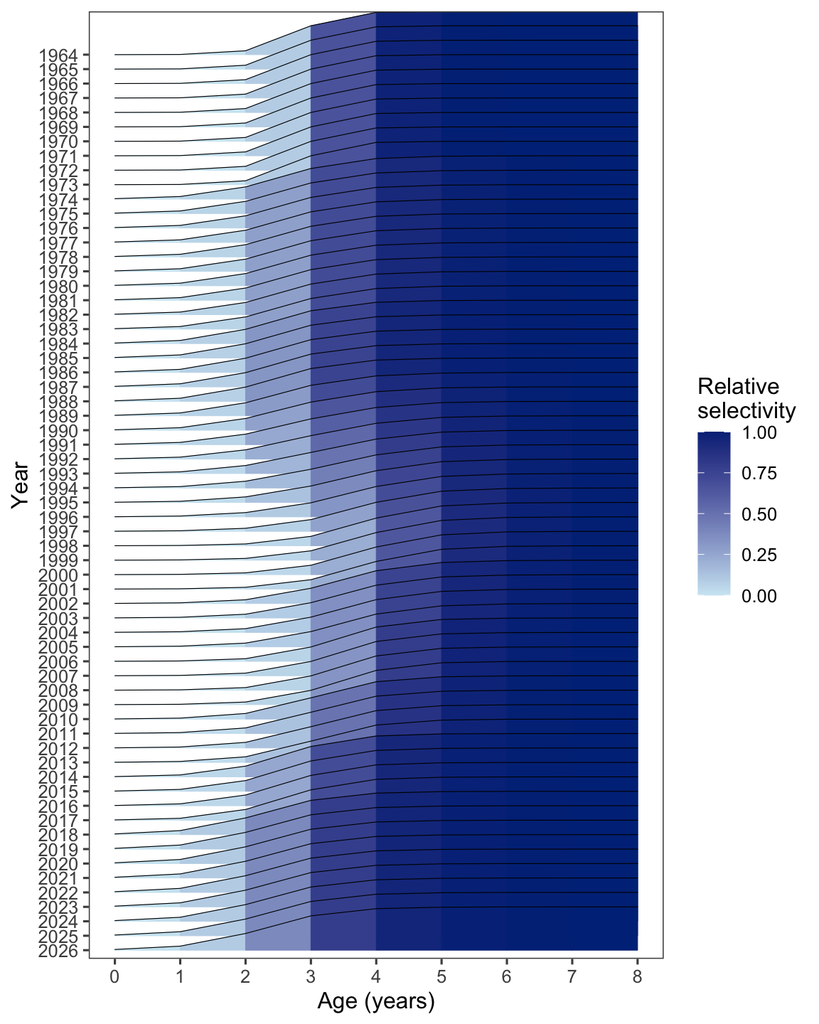

Figure 5: Time-varying fishery selectivity for the converged 2026 base model.

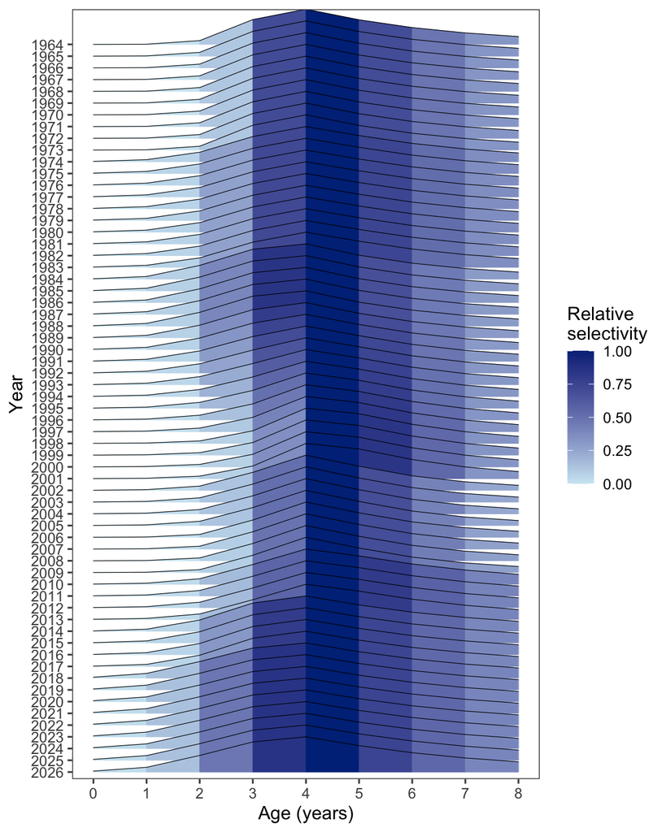

Figure 6: Time-varying fishery selectivity for the converged 2026 dome-shaped sensitivity.

## Model diagnostics and sensitivities

Table 3: Convergence diagnostics for the bridge and sensitivity models.

| Model | Objective | Maximum gradient | Status |
| --- | --- | --- | --- |
| 2025 baseline | -16.03433 | 0.00023 | Converged |
| 2026 update | -16.85233 | 0.00014 | Converged |
| q = 1.0 | 2.60241 | 0.00006 | Converged |
| q = 0.5 | 61.01969 | 0.00003 | Converged |
| Estimated M | -17.50260 | 0.00004 | Converged |
| Dome selectivity | -11.96047 | 0.00003 | Converged |
| h = 0.5 | -25.64017 | 0.00000 | Converged |
| h = 0.9 | -5.34565 | 0.00008 | Converged |

Table 4: Penalized negative-log-likelihood components by model. Lower values indicate a smaller contribution to the objective, but components should be compared within rather than across data types.

| Component | 2025 | 2026 | q = 1.0 | q = 0.5 | Est. M | Dome | h = 0.5 | h = 0.9 |
| --- | --- | --- | --- | --- | --- | --- | --- | --- |
| CPUE | -47.59 | -48.59 | -50.14 | -47.64 | -49.14 | -46.03 | -48.54 | -48.81 |
| Survey B | -33.32 | -35.31 | -23.73 | -20.50 | -34.65 | -28.02 | -35.36 | -34.96 |
| Fishery CAA | -128.12 | -126.58 | -117.09 | -67.64 | -128.28 | -129.41 | -127.07 | -124.21 |
| Survey CAA | 90.83 | 89.88 | 95.77 | 115.45 | 87.54 | 125.50 | 89.82 | 90.30 |
| Recruit | 15.81 | 16.62 | 15.99 | 9.97 | 18.06 | 8.01 | 8.56 | 25.63 |
| Sel. penalty | 35.64 | 36.14 | 33.59 | 26.87 | 37.39 | 32.25 | 35.96 | 35.92 |
| Priors | 50.73 | 50.98 | 48.21 | 44.51 | 51.57 | 25.75 | 50.99 | 50.78 |
| Total | -16.03 | -16.85 | 2.60 | 61.02 | -17.50 | -11.96 | -25.64 | -5.35 |

The one-year-old biomass index is not shown as an objective component because its likelihood weight is zero in these runs. The negative component values arise from the likelihood formulations and their estimated variance terms; they do not indicate negative lack of fit. Totals are penalized objectives, so their absolute values are most directly comparable for configurations fitted to the same observations with the same penalty structure.

The notably lower total for the (h=0.5) model is almost entirely attributable to the recruitment-residual component. Its recruitment contribution is 8.56, compared with 16.62 for the 2026 base model: a reduction of 8.07 objective units. The full objective decreases by 8.79 units, while the CPUE, survey, age-composition, selectivity-penalty, and prior components change comparatively little. With steepness fixed at 0.5, the stock–recruit curve requires smaller estimated recruitment deviations under the model’s quadratic residual penalty. Thus the lower total primarily reflects better agreement with the assumed stock–recruit relationship, not a broad improvement in fit to every observed data type or, by itself, evidence that (h=0.5) should replace the base assumption.

### Stock–recruit relationships

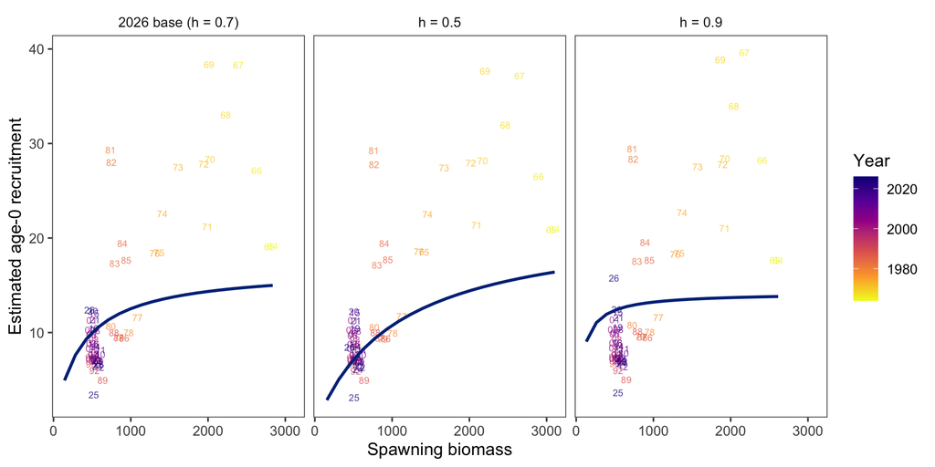

Figure 7: Fitted stock–recruit curves with annual spawning-biomass and age-0 recruitment estimates overlaid as two-digit year labels for the 2026 base model and the two fixed-steepness sensitivities.

The annual estimates, identified by the last two digits of their year, are overlaid on their corresponding fitted curves in Figure 7. The three models estimate broadly similar historical spawning biomass and recruitment, but impose different recruitment responses at low spawning biomass. The (h=0.5) curve has the weakest recruitment at low biomass, whereas (h=0.9) maintains comparatively high recruitment over the same range. The smaller recruitment-residual contribution for (h=0.5) in Table 4 means that its curve passes closer, in the model’s penalized residual metric, to the annual recruitment estimates. The wide scatter of annual estimates around all three curves nevertheless shows that the data provide limited information for choosing steepness solely from this comparison.

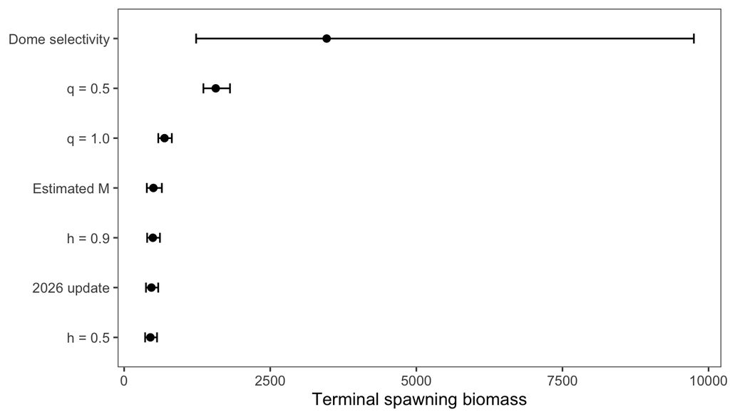

Figure 8: Terminal spawning biomass for the converged 2026 models.

# Control rule application

## Modeling Namibian hake survey data by species

Fisheries stock assessments require data that are reliably collected and compiled. Assessment models should also be configured to match the assumptions associated with the observed data. To account for survey trends between the two hake species, the estimated observation errors were applied in a state-space random-walk model. The observation model applies the observation-error variances $\sigma_{j,t}^2$ for species $j$ in year $t$. The observed indices $Z_{j,t}$ are fit to latent population trends $\hat{Z}_{j,t}$:

$$\log Z_{j,t} = \log \hat{Z}_{j,t} + \epsilon_{j,t},
\qquad \epsilon_{j,t} \sim N(0,\sigma_{j,t}^2).$$

The state equation and associated process-error variance $\tau_j^2$ is:

$$\log \hat{Z}_{j,t+1} = \log \hat{Z}_{j,t} + \eta_{j,t},
\qquad \eta_{j,t} \sim N(0,\tau_j^2).$$

The process-error variances may be shared or allowed to vary among indices, and the unobserved species population is estimated as a series of random effects. The model is fit by maximum likelihood in TMB using the [REMA package](https://afsc-assessments.github.io/rema/). Species-specific survey observations through 2026 were fit using their supplied CVs as observation-error inputs.

## Application to the Namibian hake stocks

The control rule was first applied using survey data and the relative proportions of the two hake species. A more robust formulation responds directly to the *M. paradoxus* biomass signal, independently of *M. capensis*. For this purpose, the survey smoother was fit to *M. paradoxus* alone. The long-term reference level is the geometric mean of predicted biomass from 1990 through 2026.

Figure 9 updates Figure 18 from the 2025 assessment with the 2026 *M. paradoxus* survey observation.

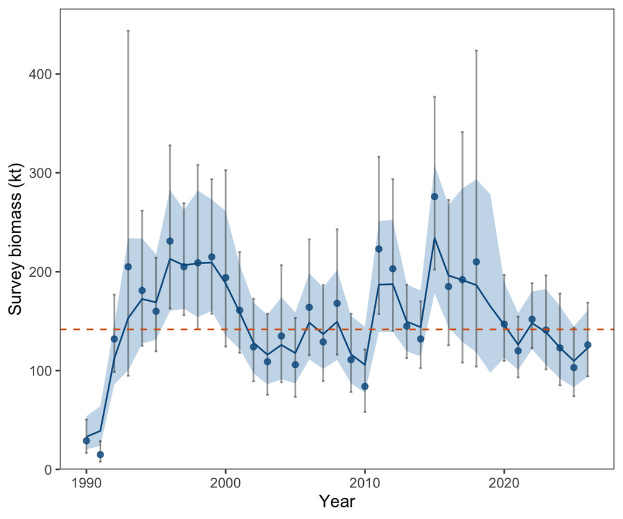

Figure 9: Historical REMA-smoothed biomass estimates for M. paradoxus and the geometric mean over 1990–2026.

The historical adjustments for three values of the species reactivity parameter $\gamma$ are shown in Figure 10. Values above the long-term mean are capped at one, so this component only reduces the combined stock advice.

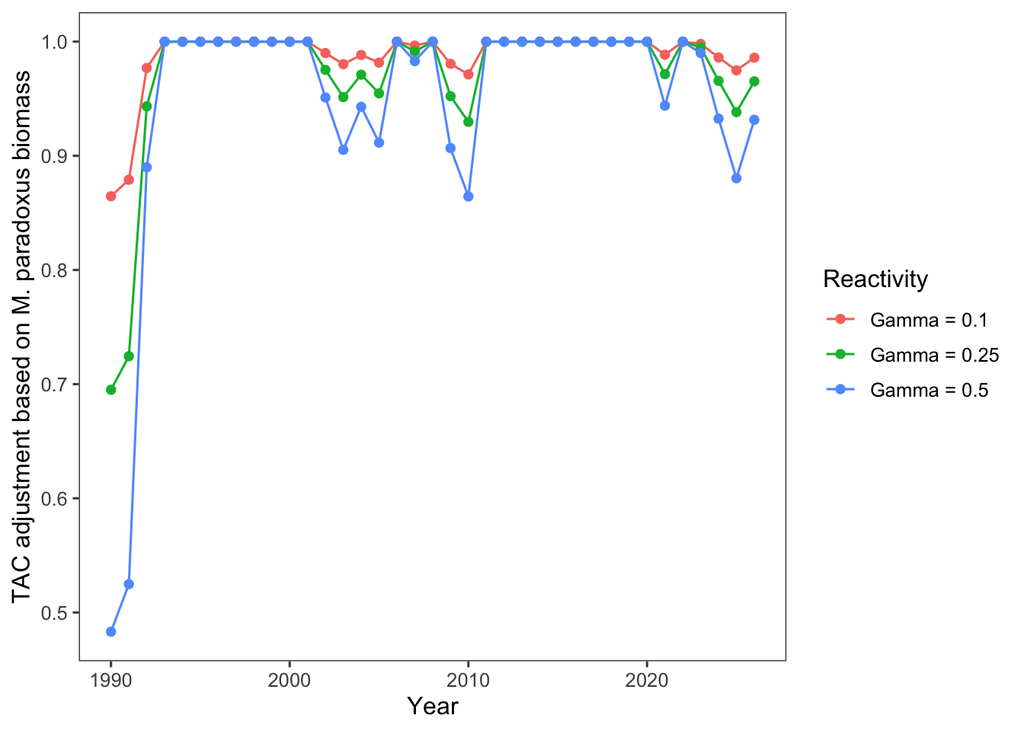

Figure 10: Historical TAC adjustment factors for alternative reactivities to M. paradoxus biomass.

## Control rule developments

The two-species control rule combines the overall biomass trend from the assessment with the species-specific survey signal. Its purpose is to reduce the exploitation rate when either combined spawning biomass or *M. paradoxus* biomass is low. The specification evaluated in the 2025 report is retained:

$$TAC_y =
\begin{cases}
0, & p_y < 0.3\bar{p}, \\
\delta
\left(\frac{1}{5}\sum_{i=0}^{4}RY_{y-i}\right)
f(B_y,\lambda)
\min\left(1,\frac{\tilde{p}_y}{\bar{p}}\right)^\gamma,
& p_y \geq 0.3\bar{p},
\end{cases}$$

where:

$$f(B_y,\lambda) =
\begin{cases}
\left(\dfrac{B_y/B_{MSY}}{0.5}\right)^\lambda,
& B_y/B_{MSY} < 0.5, \\
1, & B_y/B_{MSY} \geq 0.5.
\end{cases}$$

The rebuilding factor $\delta$ is 0.8 when spawning biomass is below $B_{MSY}$ and 1.0 otherwise. The $\lambda$ term responds when spawning biomass falls below $0.5B_{MSY}$, while $\gamma$ controls the response to the *M. paradoxus* biomass ratio.

Table 5 applies the same four $\lambda$-$\gamma$ options shown in the 2025 report to the unchanged 2025 model and the 2026 update.

Table 5: Namibian hake control-rule calculations under the options evaluated in the 2025 report.

| Statistic | 2025 baseline | 2026 update |
| --- | --- | --- |
| Recent 5-year average replacement yield | 150.754 | 149.262 |
| Current spawning biomass / BMSY | 0.521 | 0.497 |
| 2026 M. paradoxus biomass / long-term mean | 0.868 | 0.868 |
| Option 1: lambda = 1.5, gamma = 0.25 | 116.404 | 114.254 |
| Option 2: lambda = 2, gamma = 0.25 | 116.404 | 113.923 |
| Option 3: lambda = 2, gamma = 0.1 | 118.906 | 116.371 |
| Option 4: lambda = 2, gamma = 1 | 104.663 | 102.432 |

The response curves retained from the 2025 report are shown in Figure 11 and Figure 12. For the 2026 update, *M. paradoxus* predicted biomass is 0.868 of its 1990–2026 geometric mean, and the base-model spawning biomass is 0.497 of $B_{MSY}$.

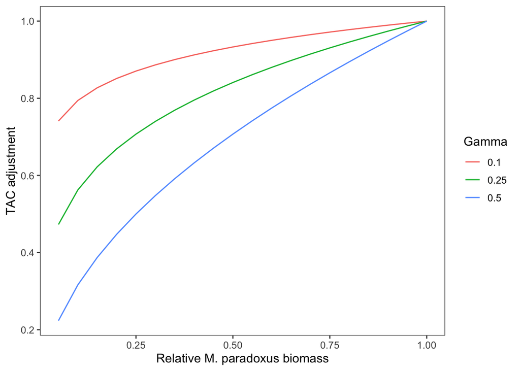

Figure 11: TAC adjustment for alternative values of gamma and relative M. paradoxus biomass.

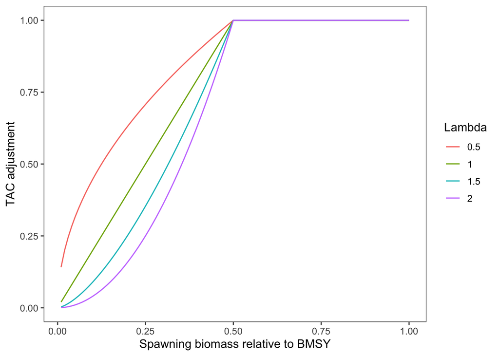

Figure 12: TAC adjustment for alternative values of lambda and spawning biomass relative to BMSY.

# Projections

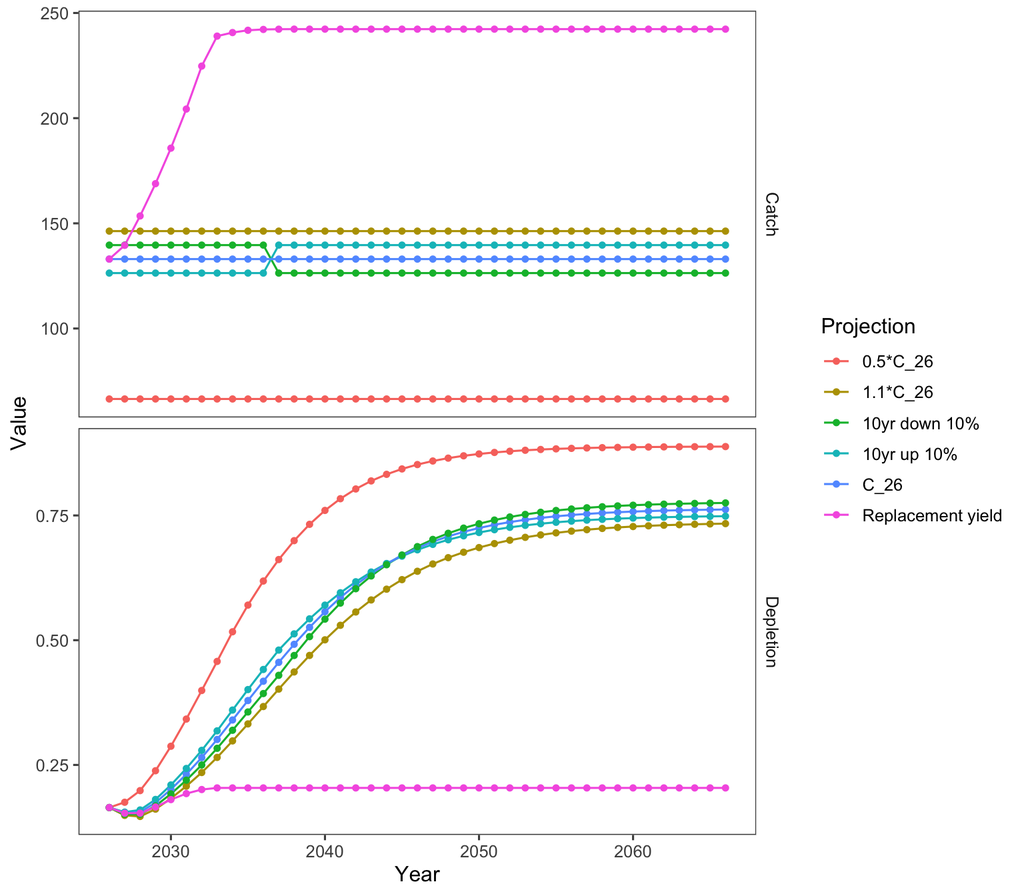

# Harvest recommendations

The ADMB model produced replacement-yield and long-term reference-point outputs for each converged configuration. A management recommendation is not presented because the final choice among control-rule options and other management inputs was not supplied as part of this update. The calculations in Table 5 reproduce the options evaluated previously and should not be interpreted as adopted TAC advice.

# Risk table and recommendation

# Status determination

The base-model estimate of spawning biomass relative to BMSY is reported in Table 1. Formal legal or management status terminology should be supplied by MFMR using the applicable Namibian framework.

# Ecosystem considerations

No new ecosystem covariates were incorporated in the assessment likelihood. The species-specific survey series is retained for evaluating the relative signals for *M. paradoxus* and *M. capensis*.

# Data gaps and research priorities

1. Evaluate the biological plausibility and stability of the regularized dome-shaped selectivity alternative before using it for management inference.
2. Document the provenance and preprocessing of each annual input block.
3. Add retrospective analyses and likelihood profiles to the operational workflow.
4. Archive the final management-procedure inputs alongside the accepted assessment.

# Acknowledgements

The assessment update was prepared by John Kathena and Jim Ianelli with data provided by the Namibian Ministry of Fisheries and Marine Resources.

# Auxiliary files

The assessment source, annual controls, automated validation tests, ADMB template, and model outputs are maintained in the `NamibianHake` repository.